# oil scan: how to

2025-06-27

# overview

## scope

This documents attempts to summarize experimental procedure(s) of hld-ift scans and to facilitate training on a hld-ift system.

## Covered topics

# HLD-IFT scan(s)

A HLD-IFT scan is series of dripping experiments where composition of outer solution (media where sample is dripped into) and inner solution (a media that is dripped into an outer solution). An HLD-IFT scan:

- creates all test solutions from specified stock solutions,
- performs the dripping experiment,
- records experimental conditions and a video of dripping dynamics

Overall workflow is represented in

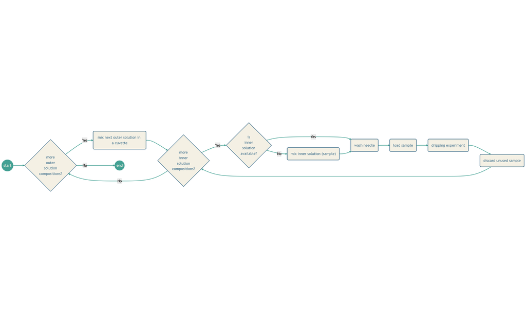

[^1]

There are two type of scans at present:

- direct scan: a 2D grid scan intended for dripping aqueous solutions into an oil phase.
- inverse scan: a 2D grid scan for dripping oil phase into an aqueous solutions (with hook-shaped needle); due to organic volatility these scans are split into few (3) chunks.

## Direct HLD-IFT scan

This is procedure to acquire dripping data for a 2D grid

This scan requires:

- 2 stock solutions for inner solution;
- 2 stock solutions for outer solution;
- scan settings file that points to all relevant configurations;

and it creates:

- new folder that is populated with:
  - logging data (`<experiment_name>\log.log`)
  - data file keeping track of various experimental metadata (`<experiment_name>\data.json`)
  - images (`<experiment_name>/<scan_name>/<measurement_name>/<image_name>.jpg`)

There are several helper scripts that help to prepare stock solutions and scan settings for this scan. These scripts assume that user uses particular layout[^2].

## inverse HLD-IFT scan

This is a modification of a direct HLD-IFT scan to be used with volatile samples. The current version splits whole scan in several (3) chunks and 2 samples (inner solutions) are tested against all selected outer solutions (such procedure limits time that container of a volatile sample has to be left open). To obtain a single inverse HLD-IFT scan several (3) scans have to be performed and data combined later.

This scan requires:

- 2 stock solutions for inner solution;
- 2 stock solutions for outer solution;
- scan settings file that points to all relevant configurations;

and it creates:

- new folder that is populated with:
  - logging data (`<experiment_name>\log.log`)
  - data file keeping track of various experimental metadata (`<experiment_name>\data.json`)
  - images (`<experiment_name>/<scan_name>/<measurement_name>/<image_name>.jpg`)

# procedure

This section aims to describe general procedure to acquire HLD-IFT scans. In general experiment can consist of 1 or multiple scans, the discussed workflow assumes that multiple scans are needed.

Below is a very generic list of operations needed to execute one or more scans:

1. evaluate surfactant solubility in oils to be used for scan
2. plan preparation of stock solution
3. make stock(s) and add their representation to a solution repository
4. make main configuration
5. make run stock (and distribute washing solution)
6. prepare scan configurations
7. check camera
8. execute scan

## surfactant solubility in oil (step 1)

1. with neat surfactant measure 2 aliquots of 0.1 g surfactants in 5 mL vials
2. with heptane and hexadecane test solubility (see solubility testing)

### solubility testing

- to 0.1g of surfactant add 0.4 mL of solution (yields ~ 20g/100ml of surfactant), note appearance
- add extra 0.25 mL of solution (~ 13.3g/100ml of surfactant), note appearance
- add extra 0.25 mL of solution (~ 10g/100ml of surfactant), note appearance
- add extra 0.50 mL of solution (~ 6.7g/100ml of surfactant), note appearance
- add extra 0.50 mL of solution (~ 5g/100ml of surfactant), note appearance
- procedure can be terminated whenever there is a clear sign that surfactant is soluble in a chosen liquid

## stock solution preparation (steps 2 and 3)

- in the context of an oil scan there are 3 parts relevant to stock solutions:
  - planning: what components and in what quantities to mix
  - actual preparation of stock solution
  - making of stock solution representation for oil scan(s) and adding to a solution repository

### planning

- Providing that surfactant is going to dissolve in a chosen oil, recipe(s) for stock(s) can be generated using `generate_recepies_for_solutions_v2.py`. The script will optimize a binary mixture from solutions (compounds) available in repository. Recipes are estimated from ingredient densities and assume no volumetric changes; the assumption is reasonably good for most solutions and any significant deviations can be accounted for with density measurement.
- to generate a recipe call execute command like:

```
python generate_recepies_for_solutions_v2.py <recipe_file>
```

- recipes needed should be specified in in `recepies` section; it can contain multiple recipes targets
- each recipe should contain following parameters:
  - solution1, solution2: string, a name of solutions (compounds) to be used to generate recipe; names of solutions should be defined in a selected solution repository
  - component_to_target: string, a name of a component which concentration is to be targeted
  - target_concentration: numeric, concentration in g/g (m/m) or g/ml (m/v) units
  - concentration_type: a string, mass (“m/m”) or mass to volume concentration (“m/v”)
  - quantity: numeric, quantity of final solution needed in grams
- script will output 3 section per each recipe:
  - instructions to make solution
  - a dictionary template to create sock solution representation
  - a serialized solution object of a stock

### stock preparation and density measurement

- make stock according to recipe by dissolving m_surfactant g of surfactant in m_solvent g of solvent
- add 5 ml (v_ro) of di water in 5 mL glass vial, note mass (m_ro_water)
- add 5 ml of stock in 5 ml vial, note mass (m_ro)
- note values of m_surfactant, m_solvent, v_ro, m_ro_water, m_ro

### define solution in a solution repository

- edit `compounds_to_add` section of to incorporate all prepared stock solutions:
  - use previously noted values of m_surfactant, m_solvent, v_ro, m_ro_water, m_ro to create dictionary for binary mixture
  - solution name could be anything as long as it describes well your stock; it will be used to reference stock in other scripts
- run script:

```
python solution_repository__edit.py <recipe_file>
```

- for an example see section: Example: plan recipe

## make main configuration

A main configuration is used by 3 different scripts:

- `2D_HLD_scan_v2__prepare_solutions.py` makes up run buffers and distributes washing solutions
- `2D_HLD_scan_v2__setup_configuration.py` prepares lower level configurations needed for a scan
- `2D_HLD_scan_v2__execute.py`: executes scan

# direct scan

### for solution prep

| slot 9 | 1 | 2 | 3 | 4 | 5 |
| --- | --- | --- | --- | --- | --- |
| A | A1 stock of surfactant in C7 12000 | A2 stock of surfactant in C16 12000 | A3 stock of C7 12000 | A4 stock of C16 12000 | A5 water 12000 |
| B | B1 run stock of surfactant in C7 0 12500 |  |  |  |  |
| C | C1 run stock of surfactant in C16 0 12500 |  |  |  |  |

| slot 2 | 1 | 2 | 3 | 4 |
| --- | --- | --- | --- | --- |
| A | A1 unused sample waste 0 500 | A2 sample rinse waste 0 500 | A3 first rinse waste 0 500 | A4 first rinse source 0 1400 |

### for 2D scan

| slot 9 | 1 | 2 | 3 | 4 |
| --- | --- | --- | --- | --- |
| A | A1 water 12000 | A2 stock of NaCl solution 12000 | A3 run stock of surfactant in C7 12000 | A4 run stock of surfactant in C16 12000 |

| slot 2 | 1 | 2 | 3 | 4 |
| --- | --- | --- | --- | --- |
| A | A1 unused sample waste 500 | A2 sample rinse waste 500 | A3 first rinse waste 500 | A4 first rinse source 1400 |

# inverse scan

### for solution prep

| slot 9 | 1 | 2 | 3 | 4 | 5 |
| --- | --- | --- | --- | --- | --- |
| A | A1 stock of surfactant in C7 12000 | A2 stock of surfactant in C16 12000 | A3 stock of C7 12000 | A4 stock of C16 12000 | A5 stock of C16 12000 |
| B | B1 surfactant in C7:C16 5:0 0 4000 | B2 surfactant in C7:C16 4:1 0 4000 | B3 surfactant in C7:C16 3:2 0 4000 | B4 surfactant in C7:C16 2:3 0 4000 | B5 surfactant in C7:C16 1:4 0 4000 |
| C | C1 surfactant in C7:C16 0:5 0 4000 | C2 | C3 | C4 | C5 |

| slot 2 | 1 | 2 | 3 | 4 |
| --- | --- | --- | --- | --- |
| A | A1 unused sample waste 0 500 | A2 sample rinse waste 0 500 | A3 first rinse waste 0 500 | A4 first rinse source 0 1400 |

### for 2D scan

| slot 9 | 1 | 2 | 3 | 4 |
| --- | --- | --- | --- | --- |
| A | A1 | A2 | A3 water 14500 | A4 NaCl stock 14500 |

| slot 2 | 1 | 2 | 3 | 4 | 5 | 6 |
| --- | --- | --- | --- | --- | --- | --- |
| A | A1 unused sample waste 500 | A2 sample rinse waste 500 | A3 first rinse waste 500 | A4 first rinse source 1400 | A5 | A6 |
| B | B1 | B2 | B3 | B4 | B5 | B6 |
| C | C1 | C2 | C3 | C4 | C5 | C6 |
| D | D1 surfactant in C7:C16 5:0 1400 | D2 surfactant in C7:C16 4:1 1400 | D3 surfactant in C7:C16 3:2 1400 | D4 surfactant in C7:C16 2:3 1400 | D5 surfactant in C7:C16 1:4 1400 | D6 surfactant in C7:C16 0:5 1400 |

# direct scan

### for solution prep

| slot 9 | 1 | 2 | 3 | 4 | 5 |
| --- | --- | --- | --- | --- | --- |
| A | A1 stock of surfactant in C7 12000 | A2 stock of surfactant in C16 12000 | A3 stock of C7 12000 | A4 stock of C16 12000 | A5 water 12000 |
| B | B1 run stock of surfactant in C7 0 12500 |  |  |  |  |
| C | C1 run stock of surfactant in C16 0 12500 |  |  |  |  |

| slot 2 | 1 | 2 | 3 | 4 |
| --- | --- | --- | --- | --- |
| A | A1 unused sample waste 0 500 | A2 sample rinse waste 0 500 | A3 first rinse waste 0 500 | A4 first rinse source 0 1400 |

### for 2D scan

| slot 9 | 1 | 2 | 3 | 4 |
| --- | --- | --- | --- | --- |
| A | A1 water 12000 | A2 stock of NaCl solution 12000 | A3 run stock of surfactant in C7 12000 | A4 run stock of surfactant in C16 12000 |

| slot 2 | 1 | 2 | 3 | 4 |
| --- | --- | --- | --- | --- |
| A | A1 unused sample waste 500 | A2 sample rinse waste 500 | A3 first rinse waste 500 | A4 first rinse source 1400 |

# inverse scan

### for solution prep

| slot 9 | 1 | 2 | 3 | 4 | 5 |
| --- | --- | --- | --- | --- | --- |
| A | A1 stock of surfactant in C7 12000 | A2 stock of surfactant in C16 12000 | A3 stock of C7 12000 | A4 stock of C16 12000 | A5 stock of C16 12000 |
| B | B1 surfactant in C7:C16 5:0 0 4000 | B2 surfactant in C7:C16 4:1 0 4000 | B3 surfactant in C7:C16 3:2 0 4000 | B4 surfactant in C7:C16 2:3 0 4000 | B5 surfactant in C7:C16 1:4 0 4000 |
| C | C1 surfactant in C7:C16 0:5 0 4000 |  |  |  |  |

| slot 2 | 1 | 2 | 3 | 4 |
| --- | --- | --- | --- | --- |
| A | A1 unused sample waste 0 500 | A2 sample rinse waste 0 500 | A3 first rinse waste 0 500 | A4 first rinse source 0 1400 |

### for 2D scan

| slot 9 | 1 | 2 | 3 | 4 |
| --- | --- | --- | --- | --- |
| A |  |  | A3 water 14500 | A4 NaCl stock 14500 |

| slot 2 | 1 | 2 | 3 | 4 | 5 | 6 |
| --- | --- | --- | --- | --- | --- | --- |
| A | A1 unused sample waste 500 | A2 sample rinse waste 500 | A3 first rinse waste 500 | A4 first rinse source 1400 |  |  |
| B |  |  |  |  |  |  |
| C |  |  |  |  |  |  |
| D | D1 surfactant in C7:C16 5:0 1400 | D2 surfactant in C7:C16 4:1 1400 | D3 surfactant in C7:C16 3:2 1400 | D4 surfactant in C7:C16 2:3 1400 | D5 surfactant in C7:C16 1:4 1400 | D6 surfactant in C7:C16 0:5 1400 |

# Examples

## Example: plan recipe

1. edit/create `__recipes_solutions.json__` file
- specify valid solution repository where other ingredients are defined
- if needed, specify solutions, ingredients that needs to be added to solution repository (e.g. define new surfactant or solvent that you are going to use)
- specify recipe that you need:
  - solutions to be used (refer to them by name exactly as in solution repository, please note `good_solvent` and `Good_Solvent` are different names!)
  - target component to be used (name exactly)
  - concentration needed
  - concentration type (m/m, m/v) needed
  - total amount needed in grams

Below is an example of `recipes_solutions.json` file prior to request:

```
{
  "solution_repository_path": "C:/Users/admin/Documents/Data/aikars/opentron/Tergitol_15_S_5_OIW_C7_C16/config/solution_repository.json",
  "compounds_to_add": [],
  "recepies": [
    {
      "solution1": "Tergitol_15_S_5",
      "solution2": "hexadecane",
      "component_to_target": "Tergitol_15_S_5",
      "target_concentration": 0.2,
      "concentration_type": "m/v",
      "quantity": 38.5
    },
    {
      "solution1": "Tergitol_15_S_5",
      "solution2": "heptane",
      "component_to_target": "Tergitol_15_S_5",
      "target_concentration": 0.2,
      "concentration_type": "m/v",
      "quantity": 36.5
    }
  ]
}
```

2. execute `generate_recepies_for_solutions_v2.py`

```
>>>cd C:\Users\admin\Documents\Data\aikars\opentron\Tergitol_15_S_5_OIW_C7_C16
>>>set SCRIPT="\\huckdfs-srv.science.ru.nl\huckdfs\RobotLab\Storage-Miscellaneous\aigars\temp\scripts"
>>>python %SCRIPT%\\generate_recepies_for_solutions_v2.py  recipes_solutions.json
```

- This will generate following output (only partially shown):

```
>
> ========================================
> optimizing for
>         component: `Tergitol_15_S_5`
>         concentration type: `m/v`
>         target: 0.2 g/ml
> Quantity: 38.5000 g
> Volume: 47.87 ml
>
> Use:
>     9.5724 g of Tergitol_15_S_5 and
>     28.9276 g of hexadecane
>
>     m(hexadecane)/m(Tergitol_15_S_5):  3.021995  g/g
>
> ------- dictionary for inclusion in solution repository -------
>
> a_dict_name = {
>     "mixture_type": "binary_mix",
>     "name": " 7.5e-01 hexadecane 2.5e-01 Tergitol_15_S_5_20260222",
>     "m_solute":   _9.5724_,
>     "m_solvent":  _28.9276_,
>     "solvent":   "hexadecane",
>     "solute":    "Tergitol_15_S_5",
>     "v_ro":       _1.0_,
>     "m_ro_water": _1.0_,
>     "m_ro":       _0.80429_,
>     "date":       "2026-02-22",
> }
>
> ------- target solution representation -------
>
> {
>   "name": " 7.5e-01 hexadecane 2.5e-01 Tergitol_15_S_5",
>   "ro": 0.8042937218822203,
>   "label": "_7.5e-01_hexadecane_2.5e-01_Tergitol_15_S_5",
>   "components": {
>     "hexadecane": {
>       "label": "hexadecane",
>       "w": 0.7513671875000002
>     },
>     "Tergitol_15_S_5": {
>       "label": "Tergitol_15_S_5",
>       "w": 0.2486328124999998
>     }
>   }
> }
>
> ========================================
> optimizing for
>         component: `Tergitol_15_S_5`
>         concentration type: `m/v`
>         target: 0.2 g/ml
> Quantity: 36.5000 g
> Volume: 49.43 ml
>
> Use:
>     9.8842 g of Tergitol_15_S_5 and
>     26.6158 g of heptane
>
>     m(heptane)/m(Tergitol_15_S_5):  2.692752  g/g
>
> ------- dictionary for inclusion in solution repository -------
>
> a_dict_name = {
>     "mixture_type": "binary_mix",
>     "name": " 2.7e-01 Tergitol_15_S_5 7.3e-01 heptane_20260222",
>     "m_solute":   _9.8842_,
>     "m_solvent":  _26.6158_,
>     "solvent":   "heptane",
>     "solute":    "Tergitol_15_S_5",
>     "v_ro":       _1.0_,
>     "m_ro_water": _1.0_,
>     "m_ro":       _0.73845_,
>     "date":       "2026-02-22",
> }
>
> ------- target solution representation -------
>
> {
>   "name": " 2.7e-01 Tergitol_15_S_5 7.3e-01 heptane",
>   "ro": 0.7384497201499135,
>   "label": "_2.7e-01_Tergitol_15_S_5_7.3e-01_heptane",
>   "components": {
>     "Tergitol_15_S_5": {
>       "label": "Tergitol_15_S_5",
>       "w": 0.27080078124999984
>     },
>     "heptane": {
>       "label": "heptane",
>       "w": 0.7291992187500002
>     }
>   }
> }
>
> ===========================================================
>
```

3. prepare a solution (physical step in a lab)

| components | suggested by recipe | actual surfactant, estimate of a solvent | actual surfactant and solvent |
| --- | --- | --- | --- |
| Tergitol 15-S-5 | 9.8842 | **9.899** | **9.899** |
| heptane | 26.6158 | 26.6556 | **26.665** |
| Tergitol 15-S-5 | 9.5724 | **9.572** | **9.572** |
| hexadecane | 28.9276 | 28.9265 | **28.956** |

This step involves a density measurement. We have been taking aliquots (e.g. 5 mL) and wieghing them. Water is used as reference, and density estimates leads to at least 3 values:

- `v_ro`: volume used
- `m_ro_water`: mass of water aliquot
- `m_ro`: mass of solution aliquot
4. edit `recipes_solutions.json` file. Add section “compounds_to_add” (compare content of a file in this step vs content in the step 1.)

```
{
  "solution_repository_path": "C:/Users/admin/Documents/Data/aikars/opentron/Tergitol_15_S_5_OIW_C7_C16/config/solution_repository.json",
  "compounds_to_add": [
  {
    "mixture_type": "binary_mix",
    "name": "20g/100mL Tergitol_15_S_5 in heptane 2026-02-11",
    "m_solute":   9.899,
    "m_solvent":  26.665,
    "solvent":   "heptane",
    "solute":    "Tergitol_15_S_5",
    "v_ro":       5.0,
    "m_ro_water": 5.00044,
    "m_ro":       3.69379,
    "date":       "2026-02-11"
  },
  {
    "mixture_type": "binary_mix",
    "name": "20g/100mL Tergitol_15_S_5 in hexadecane 2026-02-11",
    "m_solute":   9.572,
    "m_solvent":  28.956,
    "solvent":   "hexadecane",
    "solute":    "Tergitol_15_S_5",
    "v_ro":       5.0,
    "m_ro_water": 5.00044,
    "m_ro":       4.10178,
    "date":       "2026-02-11"
  },
  {
    "mixture_type": "pure_compound",
    "ro": 0.963,
    "name": "Tergitol_15_S_5",
    "label": "Tergitol_15_S_5"
  }
  ],
  "recepies": [
    {
      "solution1": "Tergitol_15_S_5",
      "solution2": "hexadecane",
      "component_to_target": "Tergitol_15_S_5",
      "target_concentration": 0.2,
      "concentration_type": "m/v",
      "quantity": 38.5
    },
    {
      "solution1": "Tergitol_15_S_5",
      "solution2": "heptane",
      "component_to_target": "Tergitol_15_S_5",
      "target_concentration": 0.2,
      "concentration_type": "m/v",
      "quantity": 36.5
    }
  ]
}
```

5. Add solution definition of stock solutions to solution repository by running:

```
>>>python %SCRIPT%\\solution_repository__edit.py recipes_solutions.json
```

This command edits `solution_repository.json` and adds two solution definitions:

```
...
  "20g/100mL Tergitol_15_S_5 in heptane 2026-02-11": {
    "components": {
      "Tergitol_15_S_5": {
        "label": "Tergitol_15_S_5",
        "w": 0.27073077343835467
      },
      "heptane": {
        "label": "heptane",
        "w": 0.7292692265616453
      }
    },
    "label": "_7.3e-01_heptane_2.7e-01_Tergitol_15_S_5",
    "name": "20g/100mL Tergitol_15_S_5 in heptane 2026-02-11",
    "ro": 0.7386929950164385
  },
  "20g/100mL Tergitol_15_S_5 in hexadecane 2026-02-11": {
    "components": {
      "Tergitol_15_S_5": {
        "label": "Tergitol_15_S_5",
        "w": 0.24844269102990033
      },
      "hexadecane": {
        "label": "hexadecane",
        "w": 0.7515573089700996
      }
    },
    "label": "_2.5e-01_Tergitol_15_S_5_7.5e-01_hexadecane",
    "name": "20g/100mL Tergitol_15_S_5 in hexadecane 2026-02-11",
    "ro": 0.8202838150242778
  },
...
```

Now these stock solutions are ready to be used in other scripts.